# Data Analysis and Lab.

Lab 12: Causal Inference

Suhwan Bong

2023-12-05

In this lab, we will examine the effect of job training program on income as a real data example. Two packages will be used, `MatchIt` and `WeightIt`. Both packages are under the maintenance of the same author and contain a wide array of popular matching and weighting methods.

# Lalonde Dataset

```r
library(MatchIt)
library(sandwich)
library(optmatch)
## Using Lalonde data
head(lalonde)
```

```
##      treat age educ   race married nodegree re74 re75       re78
## NSW1     1  37   11  black       1        1    0    0  9930.0460
## NSW2     1  22    9 hispan       0        1    0    0  3595.8940
## NSW3     1  30   12  black       0        0    0    0 24909.4500
## NSW4     1  27   11  black       0        1    0    0  7506.1460
## NSW5     1  33    8  black       0        1    0    0   289.7899
## NSW6     1  22    9  black       0        1    0    0  4056.4940
```

## No matching; constructing a pre-match matchit object

```r
no.adj <- matchit(treat ~ age + educ + race + married + nodegree + re74 + re75, data = lalonde, method = NULL, distance = "glm")
options(width = 100)
summary(no.adj)
```

```
##
## Call:
## matchit(formula = treat ~ age + educ + race + married + nodegree +
##     re74 + re75, data = lalonde, method = NULL, distance = "glm")
##
## Summary of Balance for All Data:
##            Means Treated Means Control Std. Mean Diff. Var. Ratio eCDF Mean eCDF Max
## distance          0.5774        0.1822          1.7941     0.9211    0.3774   0.6444
## age              25.8162       28.0303         -0.3094     0.4400    0.0813   0.1577
## educ             10.3459       10.2354          0.0550     0.4959    0.0347   0.1114
## raceblack         0.8432        0.2028          1.7615          .    0.6404   0.6404
## racehispan        0.0595        0.1422         -0.3498          .    0.0827   0.0827
## racewhite         0.0973        0.6550         -1.8819          .    0.5577   0.5577
## married           0.1892        0.5128         -0.8263          .    0.3236   0.3236
## nodegree          0.7081        0.5967          0.2450          .    0.1114   0.1114
## re74           2095.5737     5619.2365         -0.7211     0.5181    0.2248   0.4470
## re75           1532.0553     2466.4844         -0.2903     0.9563    0.1342   0.2876
##
## Sample Sizes:
##           Control Treated
## All           429     185
## Matched       429     185
## Unmatched       0       0
## Discarded       0       0
```

## Propensity score stratification: # of strata = 7 by default

```r
ps.str <- matchit(treat ~ age + educ + race + married + nodegree + re74 + re75, data = lalonde, method = "subclass", distance = "glm", link = "probit", subclass = 7)
summary(ps.str, un = F)
```

```
##
## Call:
## matchit(formula = treat ~ age + educ + race + married + nodegree +
##     re74 + re75, data = lalonde, method = "subclass", distance = "glm",
##     link = "probit", subclass = 7)
##
## Summary of Balance Across Subclasses
##            Means Treated Means Control Std. Mean Diff. Var. Ratio eCDF Mean eCDF Max
## distance          0.5773        0.5637          0.0629     0.8146    0.0332   0.0865
## age              25.8162       26.0752         -0.0362     0.4296    0.0908   0.2746
## educ             10.3459       10.2910          0.0273     0.6330    0.0157   0.0550
## raceblack         0.8432        0.8127          0.0840          .    0.0305   0.0305
## racehispan        0.0595        0.0638         -0.0182          .    0.0043   0.0043
## racewhite         0.0973        0.1235         -0.0885          .    0.0262   0.0262
## married           0.1892        0.2010         -0.0303          .    0.0119   0.0119
## nodegree          0.7081        0.6956          0.0275          .    0.0125   0.0125
## re74           2095.5737     2529.2393         -0.0887     1.0345    0.0498   0.2695
## re75           1532.0553     1768.8009         -0.0735     1.3183    0.0604   0.2193
##
## Sample Sizes:
##               Control Treated
## All            429.       185
## Matched (ESS)   58.92     185
## Matched        429.       185
## Unmatched        0.         0
## Discarded        0.         0
```

## 1:1 Propensity Score Matching (PSM)

```r
ps.mat <- matchit(treat ~ age + educ + race + married + nodegree + re74 + re75, data = lalonde, method = "nearest", distance = "glm", link = "probit", replace = T)
options(width = 200)
summary(ps.mat, un = F)
```

```
##
## Call:
## matchit(formula = treat ~ age + educ + race + married + nodegree +
##     re74 + re75, data = lalonde, method = "nearest", distance = "glm",
##     link = "probit", replace = T)
##
## Summary of Balance for Matched Data:
##            Means Treated Means Control Std. Mean Diff. Var. Ratio eCDF Mean eCDF Max Std. Pair Dist.
## distance          0.5773        0.5766          0.0032     0.9919    0.0031   0.0541          0.0132
## age              25.8162       26.4216         -0.0846     0.4257    0.0865   0.2324          1.3810
## educ             10.3459       10.5135         -0.0833     0.6105    0.0276   0.0919          1.0135
## raceblack         0.8432        0.8378          0.0149          .    0.0054   0.0054          0.0149
## racehispan        0.0595        0.0486          0.0457          .    0.0108   0.0108          0.0914
## racewhite         0.0973        0.1135         -0.0547          .    0.0162   0.0162          0.0912
## married           0.1892        0.1514          0.0966          .    0.0378   0.0378          0.5659
## nodegree          0.7081        0.6432          0.1427          .    0.0649   0.0649          0.8323
## re74           2095.5737     2160.6795         -0.0133     1.2450    0.0299   0.1946          0.6580
## re75           1532.0553     1585.8967         -0.0167     1.3161    0.0413   0.1730          0.7424
##
## Sample Sizes:
##               Control Treated
## All            429.       185
## Matched (ESS)   45.57     185
## Matched         84.       185
## Unmatched      345.         0
## Discarded        0.         0
```

## IPW - ATT for comparison

```r
library(WeightIt)
W <- weightit(treat ~ age + educ + race + married + nodegree + re74 + re75, data = lalonde, method = "glm", estimand = "ATT")
library(cobalt)
bal.tab(W, un = TRUE)
```

```
## Balance Measures
##                 Type Diff.Un Diff.Adj
## prop.score  Distance  1.7941  -0.0205
## age          Contin. -0.3094   0.1188
## educ         Contin.  0.0550  -0.0284
## race_black    Binary  0.6404  -0.0022
## race_hispan   Binary -0.0827   0.0002
## race_white    Binary -0.5577   0.0021
## married       Binary -0.3236   0.0186
## nodegree      Binary  0.1114   0.0184
## re74         Contin. -0.7211  -0.0021
## re75         Contin. -0.2903   0.0110
##
## Effective sample sizes
##            Control Treated
## Unadjusted  429.       185
## Adjusted     99.82     185
```

## Estimate Treatment Effects

```r
library(marginaleffects)

## Creating stratified/matched data
str.data <- match.data(ps.str)
mat.data <- match.data(ps.mat)

## PS Stratification
fit.str <- lm(re78 ~ treat, data = str.data, weights = weights)
avg_comparisons(fit.str, variables = "treat", vcov = ~subclass, newdata = subset(str.data, treat == 1), wts = "weights")
```

```
##
##   Term Contrast Estimate Std. Error    z Pr(>|z|)   S 2.5 % 97.5 %
##  treat    1 - 0     1301        879 1.48    0.139 2.8  -423   3025
##
## Columns: term, contrast, estimate, std.error, statistic, p.value, s.value, conf.low, conf.high
## Type:  response
```

Estimate: $1,301 with 95% CI = (-423, 3025)

```r
## PS 1:1 Matching
fit.mat <- lm(re78 ~ treat, data = mat.data, weights = weights)
avg_comparisons(fit.mat, variables = "treat", vcov = "HC3", newdata = subset(mat.data, treat == 1), wts = "weights")
```

```
##
##   Term Contrast Estimate Std. Error    z Pr(>|z|)   S 2.5 % 97.5 %
##  treat    1 - 0     1290        966 1.34    0.182 2.5  -603   3184
##
## Columns: term, contrast, estimate, std.error, statistic, p.value, s.value, conf.low, conf.high
## Type:  response
```

Estimate: $1,290 with 95% CI = (-603, 3184)

```r
## IPW
lalonde2 <- lalonde
lalonde2$ipw.weight <- W$weights
fit.ipw <- lm(re78 ~ treat, data = lalonde2, weights = ipw.weight)
avg_comparisons(fit.ipw, variables = "treat", vcov = "HC3", wts = "ipw.weight")
```

```
##
##   Term Contrast Estimate Std. Error    z Pr(>|z|)   S 2.5 % 97.5 %
##  treat    1 - 0     1214        831 1.46    0.144 2.8  -416   2844
##
## Columns: term, contrast, estimate, std.error, statistic, p.value, s.value, conf.low, conf.high
## Type:  response
```

## Full matching

```r
## full matching (without replacement)
ps.fullmat <- matchit(treat ~ age + educ + race + married + nodegree + re74 + re75, data = lalonde, method = "full", distance = "glm", link = "probit")
fullmat.data <- match.data(ps.fullmat)
fit.fullmat <- lm(re78 ~ treat, data = fullmat.data, weight = weights)
avg_comparisons(fit.fullmat, variables = "treat", vcov = ~subclass, newdata = subset(fullmat.data, treat == 1), wts = "weights")
```

```
##
##   Term Contrast Estimate Std. Error    z Pr(>|z|)   S 2.5 % 97.5 %
##  treat    1 - 0     1832        810 2.26   0.0237 5.4   245   3419
##
## Columns: term, contrast, estimate, std.error, statistic, p.value, s.value, conf.low, conf.high
## Type:  response
```

# Beyond the Class

The procedure for matching consists of design and analysis stages. During the design stage, the goal is to create matched pairs/sets so that matched subjects are sufficiently close enough in terms of their covariates. Thie stage consists of several tasks: (i) estimating the propensity score, (ii) choosing appropriate matching methods, and (iii) assessing covariate balance. We do not need the outcome $Y$ in this stage. We use only the treatment indicator $Z$ and covariates $X$. Doing so, transparency can be ensured. The analysis stage is quite simple. Based on the matched pairs/sets, we conduct hypothesis testing or estimate the treatment effects. Inferences can be made based on randomization inference as we covered, or we can use a weighted regression model with matching weights. Some practical issues are listed below:

- Variable selection for the propensity score model. See VanderWeele (2019).
- Nearest neighbor matching or optimal matching?
- Are there any covariates more important than the others? Do we need to match exactly on these?
- Use randomization inference or not?

The **MatchIt** package will be used. More details can be found at https://kosukeimai.github.io/MatchIt/. For general introductions to matching, see Stuart (2010).

# NSW Experiment Data + Survey Data (CPS)

## Recall the NSW experiment data

We examine the effect of the job training program on later earnings using the NSW experiment data. During this lecture, we used 185 treated and 185 control male subjects to evaluate the effect.

```r
library(DOS2)
## checking covariate balance between treated and control subjects.
summary.nsw.exp = aggregate(NSW[,3:10], list(NSW$z), FUN = mean)
colnames(summary.nsw.exp)[1] = "Treatment"
summary.nsw.exp
```

```
##   Treatment      age      edu     black       hisp   married  nodegree     re74     re75
## 1         0 25.70270 10.19459 0.8540541 0.05405405 0.2000000 0.7675676 2009.448 1485.058
## 2         1 25.81622 10.34595 0.8432432 0.05945946 0.1891892 0.7081081 2095.574 1532.055
```

```r
## Wilcoxon's signed rank statistic
wilcox.test(NSW$re78[NSW$z==1] - NSW$re78[NSW$z==0], conf.int = T)
```

```
##
##  Wilcoxon signed rank test with continuity correction
##
## data:  NSW$re78[NSW$z == 1] - NSW$re78[NSW$z == 0]
## V = 9025, p-value = 0.009934
## alternative hypothesis: true location is not equal to 0
## 95 percent confidence interval:
##   391.359 2893.626
## sample estimates:
## (pseudo)median
##       1639.558
```

```r
# wilcox.test(NSW$re78[NSW$z==1], NSW$re78[NSW$z==0], conf.int = T, paired = T)
```

## Compared to the survey data

Now, we’re going to examine the effect using the same 185 treated male subjects and other 429 controls. The 429 subjects are obtained from nonrandomized survey, CPS. Let’s see how different they are compared to the treated subjects. Can we draw a similar conclusion as we did using the randomized experiment?

```r
lalonde$black = (lalonde$race == "black")
lalonde$hisp = (lalonde$race == "hispan")
summary.nsw.obs = aggregate(lalonde[, c(2,3,10,11,5,6,7,8)], list(lalonde$treat), FUN = mean)
colnames(summary.nsw.obs)[c(1,3)] = c("Treatment", "edu")
summary.nsw = rbind(summary.nsw.obs[1,], summary.nsw.exp)
summary.nsw[,1] = c("obs_control", "exp_control", "treated")
summary.nsw
```

```
##     Treatment      age      edu     black       hisp   married  nodegree     re74     re75
## 1 obs_control 28.03030 10.23543 0.2027972 0.14219114 0.5128205 0.5967366 5619.237 2466.484
## 2 exp_control 25.70270 10.19459 0.8540541 0.05405405 0.2000000 0.7675676 2009.448 1485.058
## 3     treated 25.81622 10.34595 0.8432432 0.05945946 0.1891892 0.7081081 2095.574 1532.055
```

Our goal is to find control subjects who are comparable to the treated subjects, and then, make inferences. The control reservoir is larger than the treated reservoir. We can start with optimal pair matching. To illustrate several matching techniques, we will use the **MatchIt** package.

## Estimating the propensity score $e(x)$

We use the propensity socre model proposed by Dehejia and Wahba (1999). It uses additional terms for age and education.

```r
lalonde$age2 = (lalonde$age - mean(lalonde$age))^2
lalonde$age3 = (lalonde$age - mean(lalonde$age))^3
lalonde$educ2 = (lalonde$educ - mean(lalonde$educ))^2

## Propensity score estimation
ps.fit = glm(treat ~ age + age2 + age3 + educ + educ2 + black + hisp +
                married + nodegree + re74 + re75, family=binomial, x=T, data=lalonde)
summary(ps.fit)
```

```
##
## Call:
## glm(formula = treat ~ age + age2 + age3 + educ + educ2 + black +
##     hisp + married + nodegree + re74 + re75, family = binomial,
##     data = lalonde, x = T)
##
## Deviance Residuals:
##     Min       1Q   Median       3Q      Max
## -2.4529  -0.4498  -0.2289   0.4115   2.6899
##
## Coefficients:
##               Estimate Std. Error z value Pr(>|z|)
## (Intercept) -2.110e+00  1.432e+00  -1.473  0.14074
## age          7.431e-02  2.780e-02   2.673  0.00751 **
## age2        -1.731e-02  2.969e-03  -5.829 5.59e-09 ***
## age3         3.842e-04  1.506e-04   2.551  0.01073 *
## educ        -5.117e-02  9.194e-02  -0.557  0.57782
## educ2       -4.789e-02  1.608e-02  -2.977  0.00291 **
## blackTRUE    3.018e+00  3.058e-01   9.869  < 2e-16 ***
## hispTRUE     6.067e-01  4.617e-01   1.314  0.18876
## married     -1.497e+00  3.280e-01  -4.563 5.03e-06 ***
## nodegree     5.601e-01  4.229e-01   1.324  0.18540
## re74        -9.366e-05  3.202e-05  -2.925  0.00344 **
## re75         2.331e-05  4.814e-05   0.484  0.62818
## ---
## Signif. codes:  0 '***' 0.001 '**' 0.01 '*' 0.05 '.' 0.1 ' ' 1
##
## (Dispersion parameter for binomial family taken to be 1)
##
##     Null deviance: 751.49  on 613  degrees of freedom
## Residual deviance: 420.37  on 602  degrees of freedom
## AIC: 444.37
##
## Number of Fisher Scoring iterations: 6
```

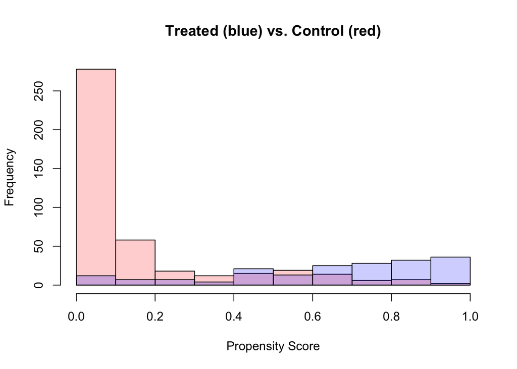

```r
est.ps = predict(ps.fit, type = "response")
hist(est.ps[lalonde$treat==0], col = rgb(1,0,0,0.2), xlab = "Propensity Score", main = "Treated (blue) vs. Control (red)")
hist(est.ps[lalonde$treat==1], col = rgb(0,0,1,0.2), add = T)
```

## Optimal Pair Matching - Using the propenstiy score Only (or PSM)

We use the estimated propensity score $e(x)$ and proceed the optimal matching procedure. To do so, we need to specify the distance matrix between treated and control subjects. We use the absolute difference, i.e, $|e({x}_t) - e({x}_c)|$. Other distances can be used; e.g., squared difference $(e({x}_t) - e({x}_c))^2$.

```r
library(optmatch)
ps.dist = match_on(est.ps, z=lalonde$treat)

psm.out = matchit(treat ~ age + educ + black + hisp + married + nodegree + re74 + re75,
                   data = lalonde, method= "optimal", distance = ps.dist)
# If you don't have a specific ps model in mind, then you could set the distance automatically.
# psm.out = matchit(treat ~ age + educ + black + hisp + married + nodegree + re74 + re75,
#                    data = lalonde, method= "optimal", distance = "glm")
summary(psm.out)
```

```
##
## Call:
## matchit(formula = treat ~ age + educ + black + hisp + married +
##     nodegree + re74 + re75, data = lalonde, method = "optimal",
##     distance = ps.dist)
##
## Summary of Balance for All Data:
##           Means Treated Means Control Std. Mean Diff. Var. Ratio eCDF Mean eCDF Max
## age             25.8162       28.0303         -0.3094     0.4400    0.0813   0.1577
## educ            10.3459       10.2354          0.0550     0.4959    0.0347   0.1114
## blackTRUE        0.8432        0.2028          1.7615          .    0.6404   0.6404
## hispTRUE         0.0595        0.1422         -0.3498          .    0.0827   0.0827
## married          0.1892        0.5128         -0.8263          .    0.3236   0.3236
## nodegree         0.7081        0.5967          0.2450          .    0.1114   0.1114
## re74          2095.5737     5619.2365         -0.7211     0.5181    0.2248   0.4470
## re75          1532.0553     2466.4844         -0.2903     0.9563    0.1342   0.2876
##
## Summary of Balance for Matched Data:
##           Means Treated Means Control Std. Mean Diff. Var. Ratio eCDF Mean eCDF Max Std. Pair Dist.
## age             25.8162       26.6486         -0.1163     0.6812    0.0376   0.1027          1.1725
## educ            10.3459       10.1297          0.1075     0.6194    0.0256   0.0865          1.1721
## blackTRUE        0.8432        0.4703          1.0259          .    0.3730   0.3730          1.1448
## hispTRUE         0.0595        0.1730         -0.4800          .    0.1135   0.1135          0.9372
## married          0.1892        0.3622         -0.4416          .    0.1730   0.1730          1.1869
## nodegree         0.7081        0.6541          0.1189          .    0.0541   0.0541          0.8561
## re74          2095.5737     3593.3165         -0.3065     1.0296    0.1360   0.4000          0.7249
## re75          1532.0553     2010.5419         -0.1486     1.1527    0.0789   0.1946          0.7734
##
## Sample Sizes:
##           Control Treated
## All           429     185
## Matched       185     185
## Unmatched     244       0
## Discarded       0       0
```

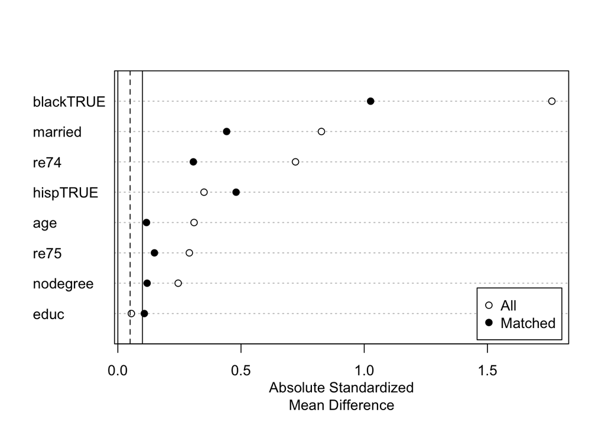

```r
plot(summary(psm.out), var.order = "unmatched")
```

The covariate balance table is shown before and after matching. We need to closely look at the column of **Std. Mean Diff**, standardized mean difference (SMD). A rule of thumb is making the SMD smaller than 0.1. We say 0.2 is acceptable, but 0.1 is preferable. As shown in the table, the balance is quite bad. Some covariates achieve good balance, but $\texttt{black}$ is not balanced at all.

## Using the rank-based Mahalanobis distance Within ps calipers

Let’s try the rank-based Mahalanobis distance within propensity score (ps) caliper. There are several options to compute this distance, but we recommend to use the **match_on** function in the **optmatch** package or the **smahal** function in the **DOS2** package.

A shortcut without computing the distance is to use the distance option *mahalanobis* or *robust_mahalanobis* in the **matchit** function in the **MatchIt** package. However, in this setting, ps caliper cannot be specified.

```r
mc.out = matchit(treat ~ age + educ + black + hisp + married + nodegree + re74 + re75,
                   data = lalonde, method= "optimal", distance = "robust_mahalanobis")
summary(mc.out, un = F)
```

```
##
## Call:
## matchit(formula = treat ~ age + educ + black + hisp + married +
##     nodegree + re74 + re75, data = lalonde, method = "optimal",
##     distance = "robust_mahalanobis")
##
## Summary of Balance for Matched Data:
##           Means Treated Means Control Std. Mean Diff. Var. Ratio eCDF Mean eCDF Max Std. Pair Dist.
## age             25.8162       26.9622         -0.1602     0.4640    0.0768   0.1514          0.6044
## educ            10.3459       10.3351          0.0054     0.5622    0.0239   0.0703          0.3280
## blackTRUE        0.8432        0.4595          1.0556          .    0.3838   0.3838          1.0556
## hispTRUE         0.0595        0.0649         -0.0229          .    0.0054   0.0054          0.0686
## married          0.1892        0.3189         -0.3312          .    0.1297   0.1297          0.3312
## nodegree         0.7081        0.6649          0.0951          .    0.0432   0.0432          0.0951
## re74          2095.5737     2731.7476         -0.1302     1.1238    0.0734   0.3351          0.3647
## re75          1532.0553     1713.2806         -0.0563     1.2924    0.0478   0.1838          0.3801
##
## Sample Sizes:
##           Control Treated
## All           429     185
## Matched       185     185
## Unmatched     244       0
## Discarded       0       0
```

Instead, we can compute the distance first, and add caliper to it. We can specify the caliper width. The default setting is 0.2. In this example, width=0.2 is too tight to solve the matching problem.

```r
smahal.dist = match_on(treat ~ age + educ + black + hisp + married + nodegree + re74 + re75,
                       data = lalonde, method="rank_mahalanobis")

### caliper width = 0.2 -> doesn't work
smahal.dist2 = smahal.dist + caliper(ps.dist, width = 0.2)
mc.out2 = matchit(treat ~ age + educ + black + hisp + married + nodegree + re74 + re75,
                              data = lalonde, method= "optimal", distance = as.matrix(smahal.dist2))
```

```
## Error in `matchit()`:
## ! No matches were found.
```

```r
### Caliper width = 1
smahal.dist3 = smahal.dist + caliper(ps.dist, width = 1)
mc.out3 = matchit(treat ~ age + educ + black + hisp + married + nodegree + re74 + re75,
                              data = lalonde, method= "optimal", distance = as.matrix(smahal.dist3))
summary(mc.out3, un = F)
```

```
##
## Call:
## matchit(formula = treat ~ age + educ + black + hisp + married +
##     nodegree + re74 + re75, data = lalonde, method = "optimal",
##     distance = as.matrix(smahal.dist3))
##
## Summary of Balance for Matched Data:
##           Means Treated Means Control Std. Mean Diff. Var. Ratio eCDF Mean eCDF Max Std. Pair Dist.
## age             25.8162       26.9622         -0.1602     0.4640    0.0768   0.1514          0.6044
## educ            10.3459       10.3351          0.0054     0.5622    0.0239   0.0703          0.3280
## blackTRUE        0.8432        0.4595          1.0556          .    0.3838   0.3838          1.0556
## hispTRUE         0.0595        0.0649         -0.0229          .    0.0054   0.0054          0.0686
## married          0.1892        0.3189         -0.3312          .    0.1297   0.1297          0.3312
## nodegree         0.7081        0.6649          0.0951          .    0.0432   0.0432          0.0951
## re74          2095.5737     2731.7476         -0.1302     1.1238    0.0734   0.3351          0.3647
## re75          1532.0553     1713.2806         -0.0563     1.2924    0.0478   0.1838          0.3801
##
## Sample Sizes:
##           Control Treated
## All           429     185
## Matched       185     185
## Unmatched     244       0
## Discarded       0       0
```

Still no significant improvement in covariate balance.

## Using the Mahalanobis distance within ps calipers with near-exact matching for black

We can directly add a penalty for black. If two subjects have different values of black, then their distance gets larger. The penalty values is $10 \times$ maximum distance.

```r
smahal.dist.black = addalmostexact(as.matrix(smahal.dist), lalonde$treat, lalonde$black, mult = 10)

mc.black.out = matchit(treat ~ age + educ + black + hisp + married + nodegree + re74 + re75,
                       data = lalonde, method= "optimal",
                       distance = as.matrix(smahal.dist.black))
summary(mc.black.out, un = F)
```

```
##
## Call:
## matchit(formula = treat ~ age + educ + black + hisp + married +
##     nodegree + re74 + re75, data = lalonde, method = "optimal",
##     distance = as.matrix(smahal.dist.black))
##
## Summary of Balance for Matched Data:
##           Means Treated Means Control Std. Mean Diff. Var. Ratio eCDF Mean eCDF Max Std. Pair Dist.
## age             25.8162       26.9297         -0.1556     0.4656    0.0759   0.1514          0.5968
## educ            10.3459       10.3730         -0.0134     0.5770    0.0225   0.0649          0.3253
## blackTRUE        0.8432        0.4703          1.0259          .    0.3730   0.3730          1.0259
## hispTRUE         0.0595        0.0649         -0.0229          .    0.0054   0.0054          0.0686
## married          0.1892        0.3243         -0.3450          .    0.1351   0.1351          0.3450
## nodegree         0.7081        0.6595          0.1070          .    0.0486   0.0486          0.1070
## re74          2095.5737     2875.0812         -0.1595     1.0613    0.0819   0.3459          0.3833
## re75          1532.0553     1743.9677         -0.0658     1.2681    0.0498   0.1838          0.3867
##
## Sample Sizes:
##           Control Treated
## All           429     185
## Matched       185     185
## Unmatched     244       0
## Discarded       0       0
```

No signficant change in matching quality.

# When there are covariates that are hard to match on?

In such cases, we need to look at the variables that are difficult to match on. The most difficult variable is black.

```r
table(lalonde$treat, lalonde$black)
```

```
##
##     FALSE TRUE
##   0   342   87
##   1    29  156
```

There is no problem in matching for non-black people. There are 29 treated and 342 control subjects. The control reservoir is much larger than the treated one. However, among black people, there are 156 treated subjects (> 87 control subjects). In this case, there are two options we can take: (1) optimal full matching, and (2) two smaller matching problems for black and non-black separately.

## Optimal full matching

The optimal full matching method consists of 1:$k$ matched sets & $k$:1 matched sets (various $k$). The value of $k$ can be very large. To avoid this situation, we usually set an option, “max.controls.” As shown in the matching output, the balance is now acceptable.

```r
m.full.out = matchit(treat ~ age + educ + married + black + hisp + nodegree + re74 + re75,
                     data= lalonde, method = "full",
                     distance = "glm", max.controls = 30)
summary(m.full.out, un = F)
```

```
##
## Call:
## matchit(formula = treat ~ age + educ + married + black + hisp +
##     nodegree + re74 + re75, data = lalonde, method = "full",
##     distance = "glm", max.controls = 30)
##
## Summary of Balance for Matched Data:
##           Means Treated Means Control Std. Mean Diff. Var. Ratio eCDF Mean eCDF Max Std. Pair Dist.
## distance         0.5774        0.5754          0.0090     0.9756    0.0074   0.0486          0.0464
## age             25.8162       24.9040          0.1275     0.4886    0.0804   0.3085          1.2837
## educ            10.3459       10.3813         -0.0176     0.5597    0.0224   0.0646          1.2157
## married          0.1892        0.1415          0.1218          .    0.0477   0.0477          0.7764
## blackTRUE        0.8432        0.8347          0.0236          .    0.0086   0.0086          0.0322
## hispTRUE         0.0595        0.0595         -0.0000          .    0.0000   0.0000          0.5523
## nodegree         0.7081        0.7058          0.0051          .    0.0023   0.0023          0.9990
## re74          2095.5737     2539.1497         -0.0908     0.9560    0.0475   0.2491          1.0120
## re75          1532.0553     1588.1445         -0.0174     1.9019    0.0679   0.2384          0.8750
##
## Sample Sizes:
##               Control Treated
## All            429.       185
## Matched (ESS)   51.33     185
## Matched        429.       185
## Unmatched        0.         0
## Discarded        0.         0
```

We can try a different link (probit) for the propensity score model. Balane is better, as determined by the lower SMD.

```r
m.full.probit.out = matchit(treat ~ age + educ + married + black + hisp + nodegree + re74 + re75,
                     data= lalonde, method = "full",
                     distance = "glm", link = "probit")
summary(m.full.probit.out, un = F)
```

```
##
## Call:
## matchit(formula = treat ~ age + educ + married + black + hisp +
##     nodegree + re74 + re75, data = lalonde, method = "full",
##     distance = "glm", link = "probit")
##
## Summary of Balance for Matched Data:
##           Means Treated Means Control Std. Mean Diff. Var. Ratio eCDF Mean eCDF Max Std. Pair Dist.
## distance         0.5773        0.5766          0.0036     0.9946    0.0042   0.0541          0.0197
## age             25.8162       25.6335          0.0255     0.4674    0.0819   0.2764          1.2686
## educ            10.3459       10.4590         -0.0562     0.6138    0.0221   0.0595          1.1950
## married          0.1892        0.1555          0.0860          .    0.0337   0.0337          0.4866
## blackTRUE        0.8432        0.8389          0.0119          .    0.0043   0.0043          0.0162
## hispTRUE         0.0595        0.0469          0.0532          .    0.0126   0.0126          0.5068
## nodegree         0.7081        0.6711          0.0814          .    0.0370   0.0370          0.9550
## re74          2095.5737     2108.4175         -0.0026     1.3485    0.0330   0.2067          0.8421
## re75          1532.0553     1557.1654         -0.0078     1.5659    0.0509   0.2059          0.8367
##
## Sample Sizes:
##               Control Treated
## All            429.       185
## Matched (ESS)   51.66     185
## Matched        429.       185
## Unmatched        0.         0
## Discarded        0.         0
```

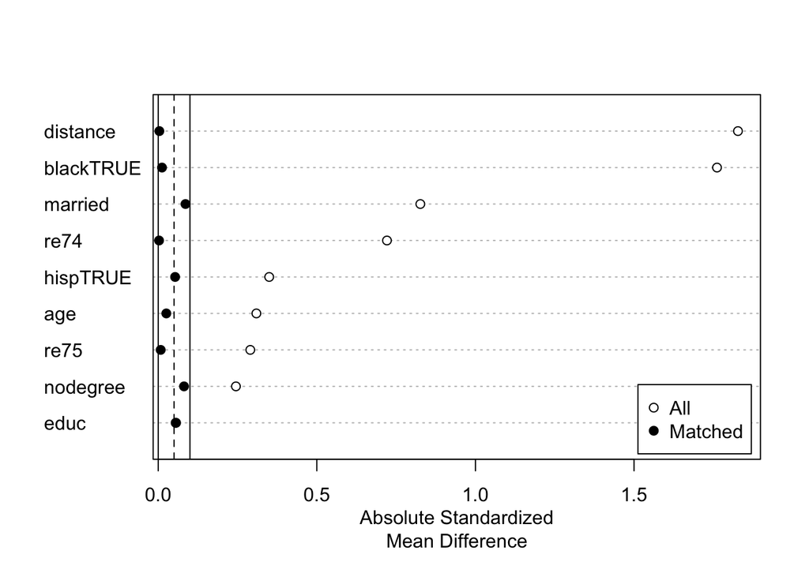

```r
plot(summary(m.full.probit.out), var.order = "unmatched")
```

## Separate optimal pair matching for black and non-black

In the full matching method, there is no thrown away subject. However, using all subjects is not always the best way for matching. There could be a loss in precision due to the weights. Subjects may be weighted in such a way that they contribute less to the sample than would unweighted subjects. **Effective sample size (ESS)** of the full matching weighted sample may be lower than even that of 1:1 pair matching.

An alternative method is to remove subjects that are not comparable. We can match exactly on black.

```r
## matching separate
m.exact.out = matchit(treat ~ age + educ + black + hisp + married + nodegree + re74 + re75,
                      data = lalonde, method= "optimal",
                      distance = "robust_mahalanobis", exact = ~black)

summary(m.exact.out, un = F)
```

```
##
## Call:
## matchit(formula = treat ~ age + educ + black + hisp + married +
##     nodegree + re74 + re75, data = lalonde, method = "optimal",
##     distance = "robust_mahalanobis", exact = ~black)
##
## Summary of Balance for Matched Data:
##           Means Treated Means Control Std. Mean Diff. Var. Ratio eCDF Mean eCDF Max Std. Pair Dist.
## age             24.7414       26.1466         -0.1964     0.4534    0.0666   0.1207          0.5313
## educ            10.2672       10.2069          0.0300     0.6052    0.0231   0.0603          0.3044
## blackTRUE        0.7500        0.7500          0.0000          .    0.0000   0.0000          0.0000
## hispTRUE         0.0948        0.0862          0.0365          .    0.0086   0.0086          0.0365
## married          0.2328        0.2672         -0.0880          .    0.0345   0.0345          0.0880
## nodegree         0.6724        0.6293          0.0948          .    0.0431   0.0431          0.0948
## re74          2803.2334     2735.4405          0.0139     1.3688    0.0262   0.1724          0.3061
## re75          1914.6811     1722.1051          0.0598     1.5669    0.0180   0.0517          0.4172
##
## Sample Sizes:
##           Control Treated
## All           429     185
## Matched       116     116
## Unmatched     313      69
## Discarded       0       0
```

# Analysis Stage

## Using randomziation inference

Optimal full matching produces matched sets with variable set sizes. Wilcoxon’s signed rank test cannot be applicable. We instead use Huber’s M-statistic. Randomization inference using this statistic is easily done with the **senfm** function in the **sensitivityfull** package.

We need to make a table for outcome first. Each row represents a matched set. The first column is always the treated outcomes.

```r
## analysis

m.full = match.data(m.full.probit.out)
subclass = as.numeric(m.full$subclass)
## outcome matrix
y.fm = matrix(NA, nrow = length(unique(subclass)), ncol = max(table(subclass)))
treat1.vec = rep(NA, length(unique(subclass)))
for(i in 1:length(unique(subclass))){
  temp.indicator = (subclass == i)
  if(sum(m.full$treat[temp.indicator]) == 1){
    y.fm[i,1] = m.full$re78[temp.indicator==1 & m.full$treat==1]
    y.fm[i,(2:sum(temp.indicator))] = m.full$re78[temp.indicator==1 & m.full$treat ==0]
    treat1.vec[i]= TRUE
  }else{
    y.fm[i,1] = m.full$re78[temp.indicator==1 & m.full$treat==0]
    y.fm[i,(2:sum(temp.indicator))] = m.full$re78[temp.indicator==1 & m.full$treat==1]
    treat1.vec[i]= FALSE
  }
}
```

Comptuing the paired outcome table for matched pairs is easier. Randomization inference can be implemented by using the **senmw** function in the **sensitivitymw** package.

```r
m.exact = match.data(m.exact.out)
y.pair = matrix(NA, nrow = length(unique(m.exact$subclass)), ncol = 2)
for(i in 1:length(unique(m.exact$subclass))){
  y.pair[i,1] = m.exact$re78[m.exact$subclass == i & m.exact$treat == 1]
  y.pair[i,2] = m.exact$re78[m.exact$subclass == i & m.exact$treat == 0]
}
```

```r
library(sensitivityfull)
senfm(y.fm, treated1 = treat1.vec)
```

```
## $pval
## [1] 0.06533123
##
## $deviate
## [1] 1.511495
##
## $statistic
## [1] 3.638079
##
## $expectation
## [1] 1.225252e-16
##
## $variance
## [1] 5.793368
```

```r
senfmCI(y.fm, treated1 = treat1.vec)
```

```
## $PointEstimates
## [1] 1197.661 1197.661
##
## $ConfidenceInterval
## [1] -358.2097 2775.2195
##
## $description
##            Coverage               Gamma Confidence Interval
##              "0.95"                 "1"         "Two-sided"
```

```r
library(sensitivitymw)
senmw(y.pair)
```

```
## $pval
## [1] 0.06952365
##
## $deviate
## [1] 1.479348
##
## $statistic
## [1] 3.805314
##
## $expectation
## [1] 0
##
## $variance
## [1] 6.616682
```

```r
senmwCI(y.pair, one.sided = F)
```

```
## $PointEstimate
## minimum maximum
##    1280    1280
##
## $Confidence.Interval
## minimum maximum
##    -430    2990
```

## Using an outcome model

We can run a simple regression of the outcome on the treatment with matching weights. Using cluster-robust standard errors is recommended. Also, using pair membership as the clustering variable is recommended.

```r
library("lmtest") # coeftest
library("sandwich") # vcovCL

fit.full = lm(re78 ~ treat, data = m.full, weights = weights)
coeftest(fit.full, vcov. = vcovCL, cluster = ~subclass)
```

```
##
## t test of coefficients:
##
##             Estimate Std. Error t value  Pr(>|t|)
## (Intercept)  4517.02     623.31  7.2468 1.291e-12 ***
## treat        1832.12     809.86  2.2623   0.02403 *
## ---
## Signif. codes:  0 '***' 0.001 '**' 0.01 '*' 0.05 '.' 0.1 ' ' 1
```

A natural question to ask is whether we can include covariates in the outcome model. One may ask, why use matching at all if you are going to model the outcome with covariates anyway? Matching reduces the dependence of the effect estimate on correct specification of the outcome model, and this is the central ideaof Ho et al. (2007).

However, searching for the best outcome model by trying many models is discouraged. Doing so can invalidate results and yield a conclusion that fails to replicate. We recommend only including the same terms inluded in the propensity score model unless there is a strong *a priori* and justifiable reason to mdeol the outcome differently.

```r
fit.full.with.cov = lm(re78 ~ treat + age + educ + black + hisp +
                         married + nodegree + re74 + re75,
                       data = m.full, weights = weights)
coeftest(fit.full.with.cov, vcov. = vcovCL, cluster = ~subclass)
```

```
##
## t test of coefficients:
##
##                Estimate  Std. Error t value  Pr(>|t|)
## (Intercept)  4.5797e+03  3.3476e+03  1.3681 0.1718026
## treat        1.9102e+03  7.9089e+02  2.4152 0.0160208 *
## age         -4.6235e+01  3.9946e+01 -1.1575 0.2475457
## educ         2.3076e+02  2.0910e+02  1.1036 0.2702147
## blackTRUE   -1.5942e+03  8.3613e+02 -1.9066 0.0570439 .
## hispTRUE    -6.2010e+02  1.5398e+03 -0.4027 0.6873122
## married      9.5414e+02  1.2067e+03  0.7907 0.4294260
## nodegree    -1.2959e+03  1.2765e+03 -1.0152 0.3103996
## re74        -7.9281e-03  1.4672e-01 -0.0540 0.9569258
## re75         5.2238e-01  1.4537e-01  3.5935 0.0003529 ***
## ---
## Signif. codes:  0 '***' 0.001 '**' 0.01 '*' 0.05 '.' 0.1 ' ' 1
```

For matched pairs, we can use

```r
fit.pair = lm(re78 ~ treat, data = m.exact, weights = weights)
coeftest(fit.pair, vcov. = vcovCL, cluster = ~subclass)
```

```
##
## t test of coefficients:
##
##             Estimate Std. Error t value  Pr(>|t|)
## (Intercept)  5344.96     604.19  8.8465 2.433e-16 ***
## treat        1777.68     981.48  1.8112   0.07141 .
## ---
## Signif. codes:  0 '***' 0.001 '**' 0.01 '*' 0.05 '.' 0.1 ' ' 1
```

Oh, wait! Why are these regression estimates so different from the estimates based on randomization inference?

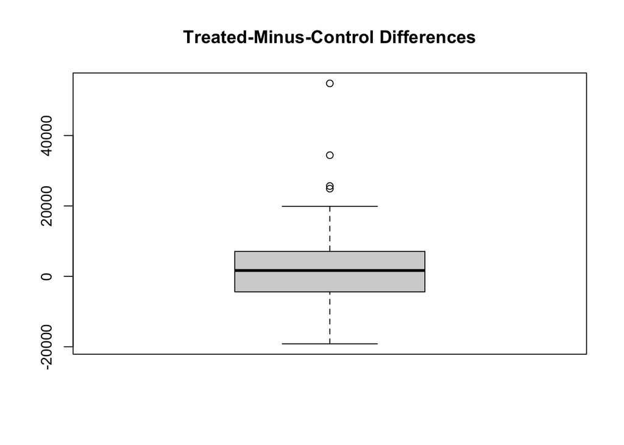

```r
boxplot(y.pair[,1] - y.pair[,2], main = "Treated-Minus-Control Differences")
```